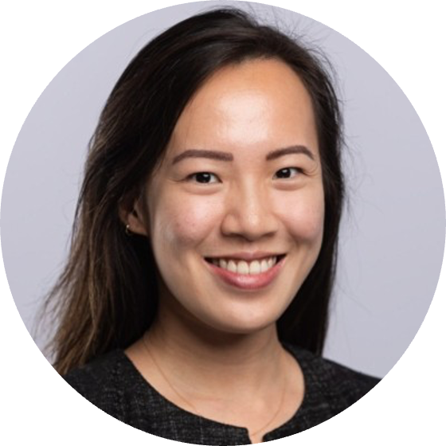

# Sharon Zhang

## Bio

Sharon attends [Johns Hopkins Bloomberg School of Public Health](https://publichealth.jhu.edu/) as a part-time MPH student concentrating in Epidemiology and Biostatistics. She also works as a Senior Product Manager at [CVS Health](https://www.cvshealth.com/), where her role focuses on optimizing use of external claims data across lines of business (Aetna, Retail, Specialty, Caremark, Healthspire).

Previously, she worked as a Senior Solutions Manager at [Flatiron Health](https://flatiron.com/), where she led knowledge management, customer success, and feature rollouts for the Real-World Evidence (RWE) business in support of cancer researchers, and as a Consultant at [Simon-Kucher](https://www.simon-kucher.com/en), where she delivered go-to-market pricing and market access strategies to support drug launches across 10+ countries. She also holds a Bachelor’s degree in Economics from the [University of Chicago](https://www.uchicago.edu/en).

Sharon is passionate about leveraging data and technology to improve health outcomes at scale, with particular interest in the areas of oncology and mental health.

## Projects

- [CHAI](https://www.clintonhealthaccess.org/our-programs/cancer/): Cleaned and analyzed patient chart-abstracted data to evaluate programmatic impact of the Nigeria Cancer Access Partnership ([NCAP](https://www.alliedagainstcancer.org/access-partnership)) on patient access to quality, affordable drugs.
- Crisis counseling: Conducted exploratory analysis to evaluate the real-world performance and impact of deploying an LLM-based copilot at scale in a WhatsApp-based crisis counseling service in India.
- ICER evaluation: Replicated an Institute for Clinical and Economic Review (ICER) cost-effectiveness analysis of non-small cell lung cancer (NSCLC) therapies using electronic health record data from Flatiron Health.

## Interests & Hobbies

- Board Games
- Hiking
- Tennis
- Puzzles
- Corgis

Last Updated: 2025-08-28